Reproducible Research Course Project 1

Load the data:

```r
setwd('D:/Data')
data <- read.csv('activity.csv')
```

Process the data (removing NAs):

```r
data1 <- data[complete.cases(data), ]
```

What is mean total number of steps taken per day?

1. Calculate the total number of steps taken per day and make a histogram:

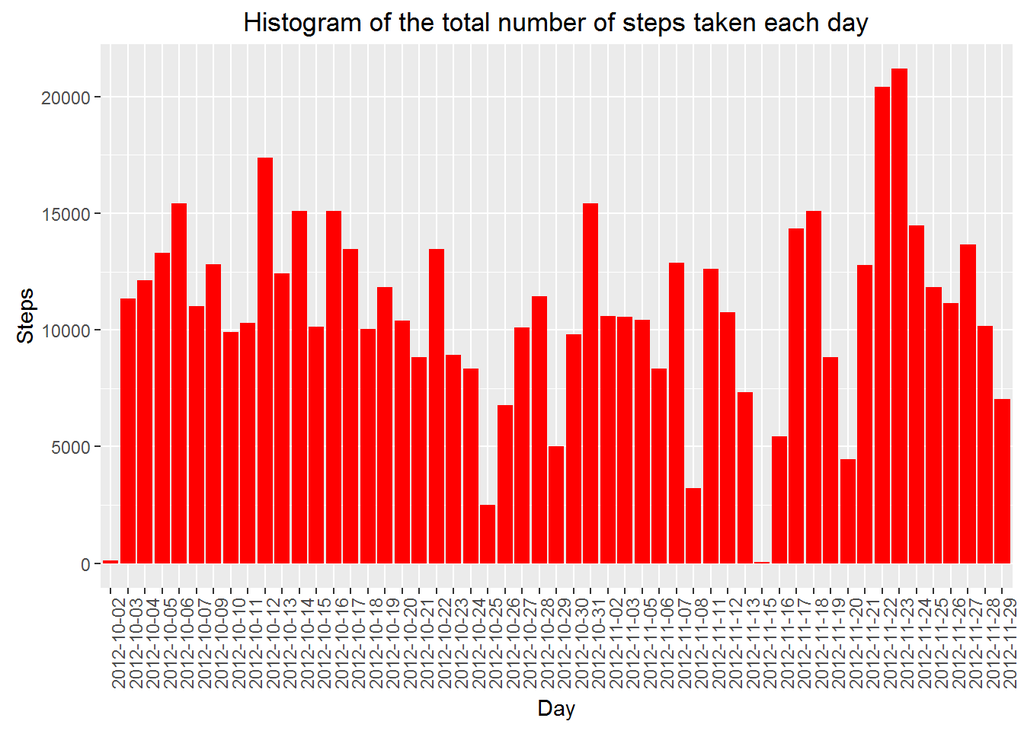

```r
library(ggplot2)
ggplot(data1, aes(as.factor(date),steps))+geom_bar(fill="red", stat="identity")+xlab("Day") + ylab("Steps")+ggtitle("Histogram of the total number of steps taken each day")+ theme(axis.text.x = element_text(angle = 90, hjust = 1))
```

2. Calculate and report the mean and median of the total number of steps taken per day:

```r
meanFreq <- as.integer(mean(aggregate(steps~date,data1, FUN=sum)$steps))
medianFreq <- median(aggregate(steps~date,data1, FUN=sum)$steps)
```

Mean and median of the total number of steps taken per day are 10766 steps and 10765 steps, respectively.

What is the average daily activity pattern?

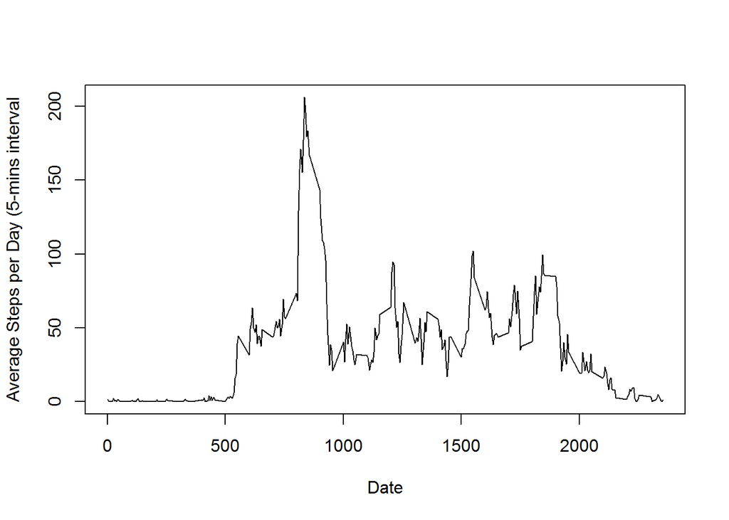

```r
data2 <- data1
data2 <- aggregate(steps~interval, data2, FUN=mean)
plot(data2$steps ~ data2$interval, type="l", xlab="Date", ylab="Average Steps per Day (5-mins interval")
```

Code to look for the maximum number of steps:

```r
maxSteps <- data2[data2$steps==max(data2$steps), ]
data2 <- NULL
```

The 5-minute interval 835, on average across all the days in the dataset, contains the maximum number of steps 206.1698113.

Imputing missing values

Calculate and report the total number of missing values in the dataset:

```r
number <- nrow(data) - nrow(data1)
```

The total number of rows with NAs in the dataset is 2304.

The simple strategy that I used in imputing the data is that I used the average steps taken for that specific interval in all of the data set and assign it to the missing value(s). The code for this strategy is the following:

```r
imputedData <- data
#The mean for that 5-minute interval
meanForNA <- aggregate(steps~interval,imputedData, FUN=mean)
for(i in 1:nrow(imputedData)){
  if(is.na(imputedData[i,c("steps")])){
    imputedData[i,c("steps")] <- meanForNA[meanForNA$interval==imputedData[i,c("interval")], c("steps")]
  }
}
```

Code to Show Histogram of the total number of steps taken each day after missing values are imputed:

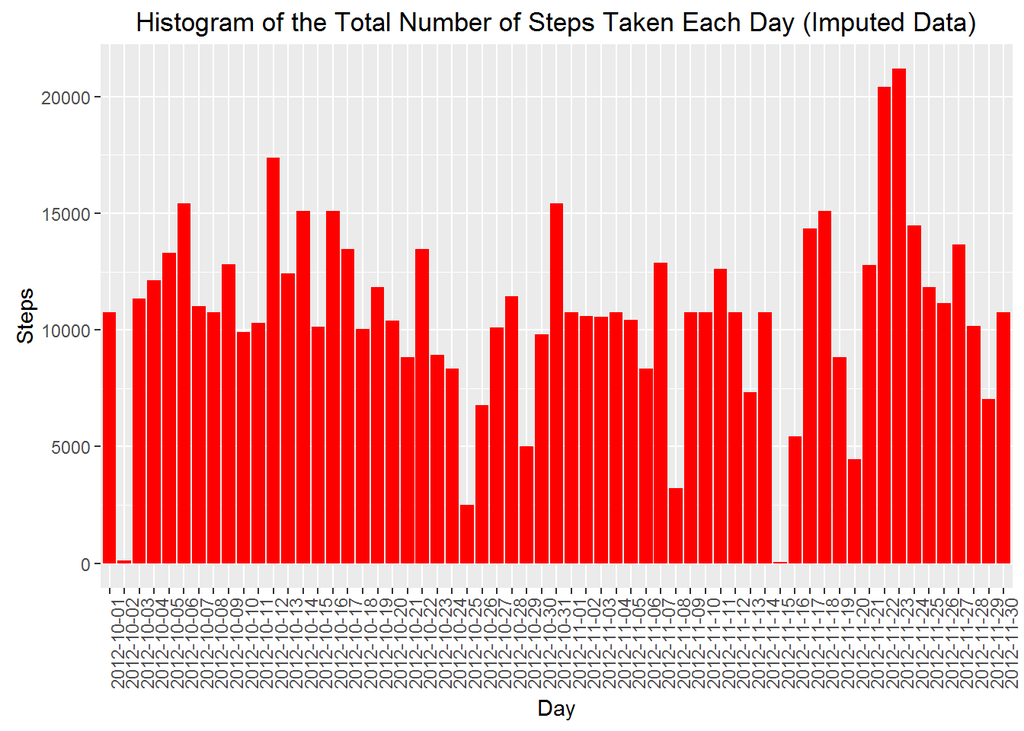

```r
ggplot(imputedData,aes(as.factor(date),steps))+geom_bar(fill="red", stat="identity")+xlab("Day") + ylab("Steps")+ggtitle("Histogram of the Total Number of Steps Taken Each Day (Imputed Data)")+ theme(axis.text.x = element_text(angle = 90, hjust = 1))
```

```r
newmeanFreq <- as.integer(mean(aggregate(steps~date,imputedData, FUN=sum)$steps))
newmedianFreq <- as.integer(median(aggregate(steps~date,imputedData, FUN=sum)$steps))
```

The new mean of the imputed data is 10766 steps compared to the old mean of 10766 steps. That creates a difference of 0 steps on average per day.

The new median of the imputed data is 10766 steps compared to the old median of 10765 steps. That creates a difference of 1 steps for the median.

This shows that the overall shape of the distribution has not changed after applying the method in imputing the data.

```r
weekDayEnd <- data.frame("dayType"=character(0))
weekDayEnd <- NULL

#Check wether the day is a weekday or weekend (Saturday)
weekInd <- function(day){
  if (weekdays(day)=="Saturday") {
    out <- "Weekend"
  } else {
    out <- "Weekday"
  }
  out
}

for (i in 1:nrow(imputedData)){
  date <- imputedData[i,c("date")]
  newObs <- data.frame("dayType"= weekInd(as.Date(date)))
  weekDayEnd <- rbind(weekDayEnd, newObs)
}
#------------------------------------------------------------

#Add the day type column in the data set
imputedData <- cbind(imputedData, weekDayEnd)
```

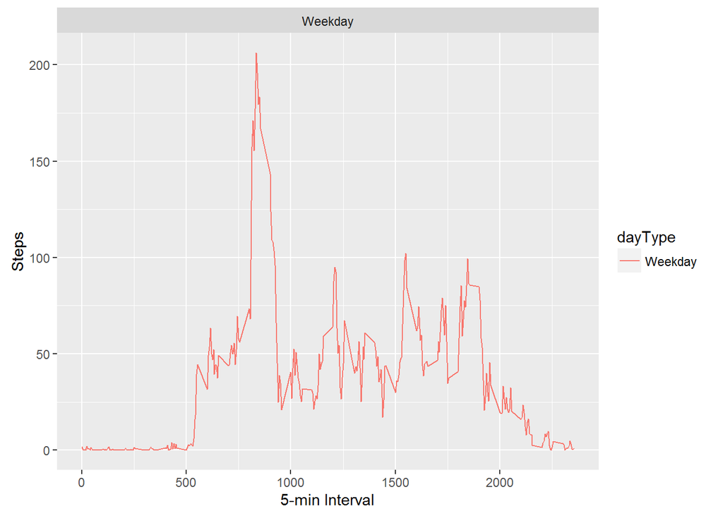

```r
averageWeekDayEnd<-aggregate(steps~interval + dayType, imputedData, FUN=mean)
ggplot(averageWeekDayEnd,aes(interval,steps, color=dayType))+geom_line()+facet_grid(. ~ dayType)+xlab("5-min Interval")+ylab("Steps")+guides(fill=FALSE)
```

Reference: https://rpubs.com/skycrater/180134